# Лабораторная работа № 1

Задача о погоне

Анна Светцова

1132230807@pfur.ru

Российский университет дружбы народов

2026-10-07

# Информация

## Докладчик

**Анна Светцова**

Российский университет дружбы народов

1132230807@pfur.ru

# Вводная часть

## Актуальность

- Задачи преследования возникают в навигации и поисковых системах
- Для выбора стратегии движения необходимо построить математическую модель
- Модель позволяет определить траекторию, обеспечивающую перехват цели

## Цель работы

Построить математическую модель задачи о погоне и определить траекторию движения катера, позволяющую перехватить лодку.

Дополнительно:

- рассмотреть два начальных случая;
- найти точки пересечения траекторий;
- исследовать влияние отношения скоростей.

## Исходные данные

Для варианта 58:

- расстояние между катером и лодкой: $k=20.2$ км;
- отношение скоростей: $n=5.1$;
- лодка движется прямолинейно;
- направление для вычислительного эксперимента: $\varphi=3\pi/4$.

## Первый этап движения

Катер сначала движется прямолинейно, пока его расстояние от точки обнаружения лодки не станет равным расстоянию, пройденному лодкой.

Для двух случаев:

$$x_1=\frac{k}{n+1},
\qquad
x_2=\frac{k}{n-1}.$$

Для варианта 58:

$$x_1 \approx 3.31 \text{ км},
\qquad
x_2 \approx 4.93 \text{ км}.$$

## Дифференциальная модель

Радиальная скорость катера равна скорости лодки:

$$\frac{dr}{dt}=v.$$

Тангенциальная составляющая:

$$v_\tau=v\sqrt{n^2-1}.$$

После исключения времени:

$$\frac{dr}{d\theta}
=
\frac{r}{\sqrt{n^2-1}}.$$

## Траектория катера

Решением уравнения является логарифмическая спираль:

$$r(\theta)=
r_0
\exp\left(
\frac{\theta-\theta_0}{\sqrt{n^2-1}}
\right).$$

После нахождения $r(\theta)$ выполняется переход к декартовым координатам:

$$x=r\cos\theta,
\qquad
y=r\sin\theta.$$

## Первый случай

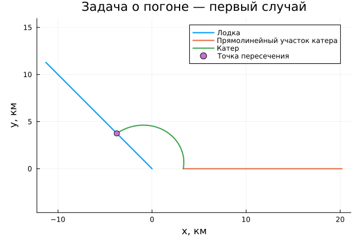

Для первого случая точка перехвата находится ближе к точке обнаружения лодки.

## Второй случай

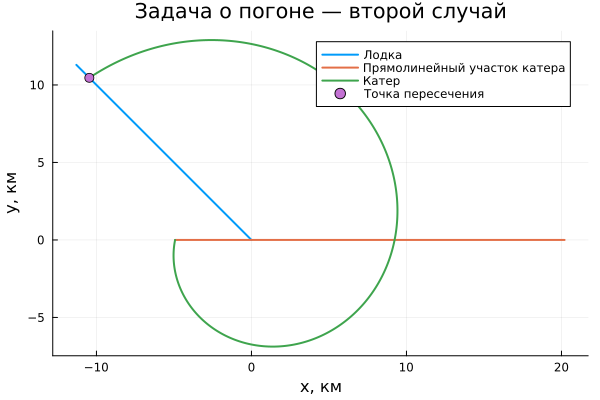

Во втором начальном случае катеру требуется пройти существенно больший путь до пересечения траекторий.

## Сравнение траекторий

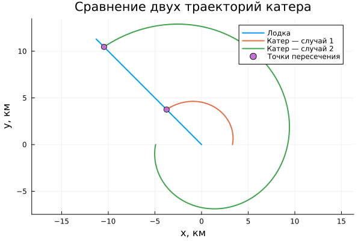

Два начальных положения приводят к различным точкам перехвата при одинаковых параметрах движения.

## Точки пересечения

Для выбранного направления движения лодки получены приблизительные координаты:

| Случай | $x$, км | $y$, км |
| --- | --- | --- |
| Первый | -3.75 | 3.75 |
| Второй | -10.46 | 10.46 |

Таким образом, первый случай приводит к более раннему перехвату.

## Параметрическое исследование

Исследовались значения:

$$n=3,\;4,\;5.1,\;6.$$

При каждом значении заново вычислялись:

- начальный радиус;
- траектория катера;
- радиус и координаты точки перехвата.

## Влияние отношения скоростей

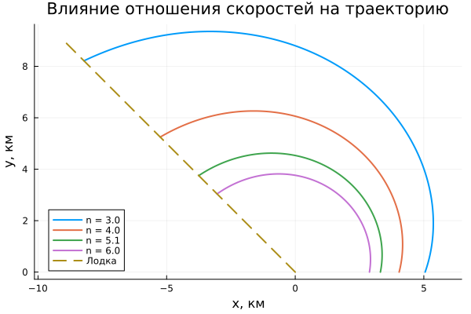

При увеличении отношения скоростей катер получает большее преимущество, а точка перехвата приближается к началу координат.

## Воспроизводимость

Расчёты оформлены в литературном стиле.

Из исходников сформированы:

- Julia-скрипты;
- Jupyter Notebook;
- документация Quarto.

Основной и параметрический эксперименты были выполнены отдельно.

## Результаты

В ходе работы:

- выведено общее дифференциальное уравнение;
- получена логарифмическая спираль движения катера;
- рассмотрены два начальных случая;
- найдены точки пересечения;
- проведено параметрическое исследование.

## Вывод

Математическая модель показывает, что после начального прямолинейного участка оптимальная траектория катера представляет собой логарифмическую спираль.

Увеличение преимущества катера по скорости позволяет осуществить перехват раньше.